# Fetal Health Classification

## Vasundhara Bagchi and Veda Singireddy

## Introduction

Through this project, we are aiming to use fetal health data to understand and classify the health of a fetus as Normal, Suspect or Pathological We are doing this using CTG (Cardiotocogram) data.

Classificaton of fetal health into these three criteria is of utmost importance as this helps reduce child and maternal mortality. As per The United Nations' Sustainable Development Goals, reduction of child mortality is a key indicator of human progress. The SDGs seek massive reductions in mortality ralte, and aim to have a a neonatal mortality rate of 12 or fewer deaths per 1,000 live births, and an under-five mortality rate of 25 or fewer deaths per 1,000 live births, by 2030. However, more than 5 million children died before their fifth birthday in 2020.

In a similar light, in lower-income and lower-resource areas, there is still a shocking number of deaths of the mother during, before, and after childbirth due to complications which could be preventable with some fetal moniroting and care. This leads to very high maternal mortality rate, but more importantly the preventable loss of countless lives. We aim to try and build a model to move closer to this important goal of reducing child and maternal mortality through classification of CTG data, our primary motivation in choosing this path for our project. CTG is an easy to use, low-cost, accessible option to get information about the health of a fetus, which allows healthcare providers to work towards diagnosis and choosing the right treatment path to reduce child and maternal mortality. CTG works by sending ultrasound waves in pulses to get data on fetal heart rate, uterine contractions, fetal movements, and more.

We plan on using the aforementioned data to classify the health of a fetus as Normal, Suspect or Pathological.

Source credit: Ayres de Campos et al. (2000) SisPorto 2.0 A Program for Automated Analysis of Cardiotocograms. J Matern Fetal Med 5:311-318 https://onlinelibrary.wiley.com/doi/10.1002/1520-6661(200009/10)9:5%3C311::AID-MFM12%3E3.0.CO;2-9

More information on child mortality health: https://www.who.int/news/item/20-12-2021-latest-child-mortality-estimates-reveal-world-remains-off-track-to-meeting-sustainable-development-goals

## Reading in the Data

**Import Statements**

```python
import numpy as np
import pandas as pd
import seaborn as sns
import matplotlib.pyplot as plt
from scipy import stats
from sklearn.model_selection import train_test_split
from sklearn.metrics import accuracy_score, classification_report,confusion_matrix
```

**Reading CSV**

```python
data = pd.read_csv('fetal_health.csv')
data.head()
```

|  | baseline value | accelerations | fetal_movement | uterine_contractions | light_decelerations | severe_decelerations | prolongued_decelerations | abnormal_short_term_variability | mean_value_of_short_term_variability | percentage_of_time_with_abnormal_long_term_variability | ... | histogram_min | histogram_max | histogram_number_of_peaks | histogram_number_of_zeroes | histogram_mode | histogram_mean | histogram_median | histogram_variance | histogram_tendency | fetal_health |
| --- | --- | --- | --- | --- | --- | --- | --- | --- | --- | --- | --- | --- | --- | --- | --- | --- | --- | --- | --- | --- | --- |
| 0 | 120.0 | 0.000 | 0.0 | 0.000 | 0.000 | 0.0 | 0.0 | 73.0 | 0.5 | 43.0 | ... | 62.0 | 126.0 | 2.0 | 0.0 | 120.0 | 137.0 | 121.0 | 73.0 | 1.0 | 2.0 |
| 1 | 132.0 | 0.006 | 0.0 | 0.006 | 0.003 | 0.0 | 0.0 | 17.0 | 2.1 | 0.0 | ... | 68.0 | 198.0 | 6.0 | 1.0 | 141.0 | 136.0 | 140.0 | 12.0 | 0.0 | 1.0 |
| 2 | 133.0 | 0.003 | 0.0 | 0.008 | 0.003 | 0.0 | 0.0 | 16.0 | 2.1 | 0.0 | ... | 68.0 | 198.0 | 5.0 | 1.0 | 141.0 | 135.0 | 138.0 | 13.0 | 0.0 | 1.0 |
| 3 | 134.0 | 0.003 | 0.0 | 0.008 | 0.003 | 0.0 | 0.0 | 16.0 | 2.4 | 0.0 | ... | 53.0 | 170.0 | 11.0 | 0.0 | 137.0 | 134.0 | 137.0 | 13.0 | 1.0 | 1.0 |
| 4 | 132.0 | 0.007 | 0.0 | 0.008 | 0.000 | 0.0 | 0.0 | 16.0 | 2.4 | 0.0 | ... | 53.0 | 170.0 | 9.0 | 0.0 | 137.0 | 136.0 | 138.0 | 11.0 | 1.0 | 1.0 |

5 rows × 22 columns

## Understanding the Data

First, we drop the histogram-related columns because we want to work with the raw data collected of each record.

```python
data = data.drop(['histogram_width', 'histogram_min', 'histogram_max', 'histogram_number_of_peaks', 'histogram_number_of_zeroes',
                  'histogram_mode', 'histogram_mean', 'histogram_median', 'histogram_variance', 'histogram_tendency'], axis=1)
data
```

|  | baseline value | accelerations | fetal_movement | uterine_contractions | light_decelerations | severe_decelerations | prolongued_decelerations | abnormal_short_term_variability | mean_value_of_short_term_variability | percentage_of_time_with_abnormal_long_term_variability | mean_value_of_long_term_variability | fetal_health |
| --- | --- | --- | --- | --- | --- | --- | --- | --- | --- | --- | --- | --- |
| 0 | 120.0 | 0.000 | 0.000 | 0.000 | 0.000 | 0.0 | 0.0 | 73.0 | 0.5 | 43.0 | 2.4 | 2.0 |
| 1 | 132.0 | 0.006 | 0.000 | 0.006 | 0.003 | 0.0 | 0.0 | 17.0 | 2.1 | 0.0 | 10.4 | 1.0 |
| 2 | 133.0 | 0.003 | 0.000 | 0.008 | 0.003 | 0.0 | 0.0 | 16.0 | 2.1 | 0.0 | 13.4 | 1.0 |
| 3 | 134.0 | 0.003 | 0.000 | 0.008 | 0.003 | 0.0 | 0.0 | 16.0 | 2.4 | 0.0 | 23.0 | 1.0 |
| 4 | 132.0 | 0.007 | 0.000 | 0.008 | 0.000 | 0.0 | 0.0 | 16.0 | 2.4 | 0.0 | 19.9 | 1.0 |
| ... | ... | ... | ... | ... | ... | ... | ... | ... | ... | ... | ... | ... |
| 2121 | 140.0 | 0.000 | 0.000 | 0.007 | 0.000 | 0.0 | 0.0 | 79.0 | 0.2 | 25.0 | 7.2 | 2.0 |
| 2122 | 140.0 | 0.001 | 0.000 | 0.007 | 0.000 | 0.0 | 0.0 | 78.0 | 0.4 | 22.0 | 7.1 | 2.0 |
| 2123 | 140.0 | 0.001 | 0.000 | 0.007 | 0.000 | 0.0 | 0.0 | 79.0 | 0.4 | 20.0 | 6.1 | 2.0 |
| 2124 | 140.0 | 0.001 | 0.000 | 0.006 | 0.000 | 0.0 | 0.0 | 78.0 | 0.4 | 27.0 | 7.0 | 2.0 |
| 2125 | 142.0 | 0.002 | 0.002 | 0.008 | 0.000 | 0.0 | 0.0 | 74.0 | 0.4 | 36.0 | 5.0 | 1.0 |

2126 rows × 12 columns

### Description of remaining columns:

1. baseline value: Baseline Fetal Heart Rate (FHR) (number of beats per minute)
2. accelerations: Number of accelerations (short term rises of heart rate) per second
3. fetal_movement: Number of fetal movements per second
4. uterine_contractions: Number of uterine contractions per second
5. light_decelerations: Number of LDs per second
6. severe_decelerations: Number of SDs per second
7. prolongued_decelerations: Number of PDs per second
8. abnormal_short_term_variability: Percentage of time with abnormal short term variability
9. mean_value_of_short_term_variability: Mean value of short term variability
10. percentage_of_time_with_abnormal_long_term_variability: Percentage of time with abnormal long term variability
11. mean_value_of_long_term_variability: Mean value of long term variability
12. fetal_health: fetal health classified in 3 ways: 1 = Normal, 2 = Suspect, 3 = Pathological

We want to understand the count, center, and spread of our data to get a better idea of the shape of our data.

```python
data.describe().T
```

|  | count | mean | std | min | 25% | 50% | 75% | max |
| --- | --- | --- | --- | --- | --- | --- | --- | --- |
| baseline value | 2126.0 | 133.303857 | 9.840844 | 106.0 | 126.000 | 133.000 | 140.000 | 160.000 |
| accelerations | 2126.0 | 0.003178 | 0.003866 | 0.0 | 0.000 | 0.002 | 0.006 | 0.019 |
| fetal_movement | 2126.0 | 0.009481 | 0.046666 | 0.0 | 0.000 | 0.000 | 0.003 | 0.481 |
| uterine_contractions | 2126.0 | 0.004366 | 0.002946 | 0.0 | 0.002 | 0.004 | 0.007 | 0.015 |
| light_decelerations | 2126.0 | 0.001889 | 0.002960 | 0.0 | 0.000 | 0.000 | 0.003 | 0.015 |
| severe_decelerations | 2126.0 | 0.000003 | 0.000057 | 0.0 | 0.000 | 0.000 | 0.000 | 0.001 |
| prolongued_decelerations | 2126.0 | 0.000159 | 0.000590 | 0.0 | 0.000 | 0.000 | 0.000 | 0.005 |
| abnormal_short_term_variability | 2126.0 | 46.990122 | 17.192814 | 12.0 | 32.000 | 49.000 | 61.000 | 87.000 |
| mean_value_of_short_term_variability | 2126.0 | 1.332785 | 0.883241 | 0.2 | 0.700 | 1.200 | 1.700 | 7.000 |
| percentage_of_time_with_abnormal_long_term_variability | 2126.0 | 9.846660 | 18.396880 | 0.0 | 0.000 | 0.000 | 11.000 | 91.000 |
| mean_value_of_long_term_variability | 2126.0 | 8.187629 | 5.628247 | 0.0 | 4.600 | 7.400 | 10.800 | 50.700 |
| fetal_health | 2126.0 | 1.304327 | 0.614377 | 1.0 | 1.000 | 1.000 | 1.000 | 3.000 |

Luckily, the count shows that all columns have a value for each row in the data.

Looking at our target variable of **fetal health**, let's look at how many classes there are.

```python
data["fetal_health"].value_counts()
```

```
1.0    1655
2.0     295
3.0     176
Name: fetal_health, dtype: int64
```

It looks like there are 3 classes - 1.0, 2.0, 3.0

The data is **imbalanced** as it ~78% of its data points are of class 1.0

We can see this with a visualization here:

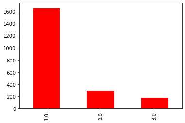

```python
data["fetal_health"].value_counts().plot(kind='bar', color = "red")
```

This hints that when building the training and testing datasets for our model later in this report, we will have to stratify our data to preserve this proportionality.

We want to understand the correlation of the different columns given in our data, so we can have an **overall correlation table** in the form of a heatmap

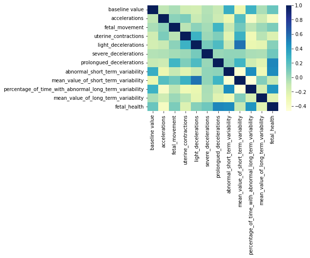

```python
dataplot = sns.heatmap(data.corr(), cmap="YlGnBu")

# displaying heatmap
plt.show()
```

More importantly, though, we want to understand the correlation of other columns with our target variable - fetal health

Let's look at this through data first, then a visualization with a heatmap.

```python
data.corr()['fetal_health'].sort_values(ascending=False)
```

```
fetal_health                                              1.000000
prolongued_decelerations                                  0.484859
abnormal_short_term_variability                           0.471191
percentage_of_time_with_abnormal_long_term_variability    0.426146
baseline value                                            0.148151
severe_decelerations                                      0.131934
fetal_movement                                            0.088010
light_decelerations                                       0.058870
mean_value_of_short_term_variability                     -0.103382
uterine_contractions                                     -0.204894
mean_value_of_long_term_variability                      -0.226797
accelerations                                            -0.364066
Name: fetal_health, dtype: float64
```

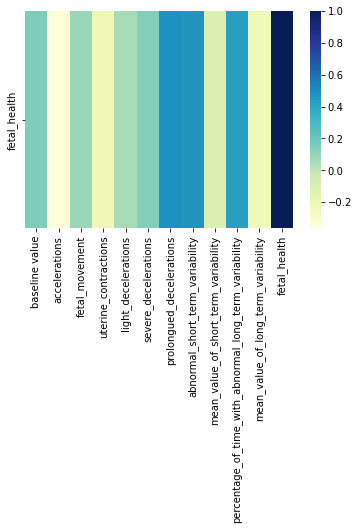

```python
sns.heatmap(data.corr().loc[['fetal_health'],:], cmap="YlGnBu")
```

We can see from the data and the heatmap that fetal health has a **strong positive correlation** with prolongued_decelerations, abnormal_short_term_variability, and percentage_of_time_with_abnormal_long_term_variability.

Let's make a violin plot to look at the distributions of these variables in relation to their fetal classification.

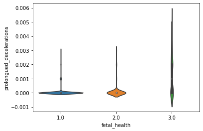

```python
sns.violinplot(x='fetal_health', y='prolongued_decelerations', data=data)
```

Records classified as Pathological (3.0) have sparsely distributed 'prolongued_decelerations' values, while those classified as Normal (1.0) and Suspect (2.0) are very concentrated near 0.

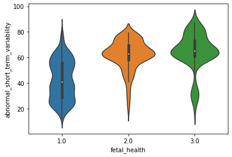

```python
sns.violinplot(x='fetal_health', y='abnormal_short_term_variability', data=data)
```

The concentration of records classified as 2.0 and 3.0 in higher values shows that of fetuses that are Suspect (2.0) or Pathological (3.0), most of them have higher abnormal short term variability than Normal (1.0) fetuses.

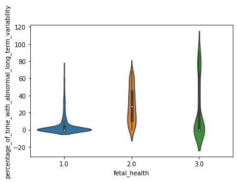

```python
sns.violinplot(x='fetal_health', y='percentage_of_time_with_abnormal_long_term_variability', data=data)
```

There is a noticeable concentration at lower values among records classified as Normal (1.0) while the others are relatively spread out, indicating that 'percentage_of_time_with_abnormal_long_term_variability' may have a larger influence on classification than other variables.

**Visualizing the spread of the different variables via a histogram**

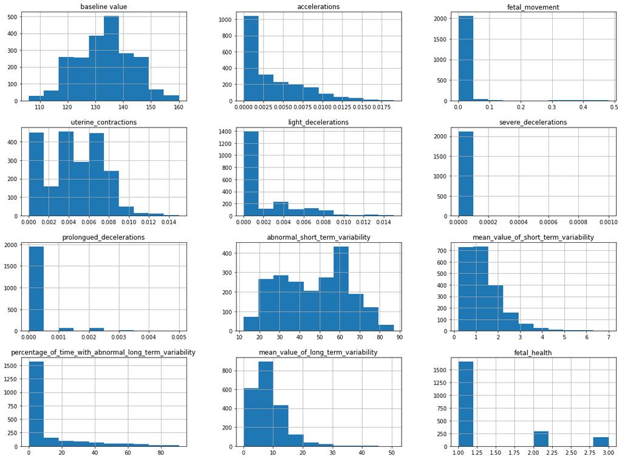

```python
data.hist(figsize=(20,15))
plt.show()
```

Among the histograms, the fetal_movement, severe_decelerations, and prolongued_deceleration columns look exceptionally imbalanced to a single value. Let's look at the value counts for each of these.

```python
data['severe_decelerations'].unique()
data[['severe_decelerations','fetal_health']].value_counts()
```

```
severe_decelerations  fetal_health
0.000                 1.0             1654
                      2.0              295
                      3.0              170
0.001                 3.0                6
                      1.0                1
dtype: int64
```

```python
data['prolongued_decelerations'].unique()
data[['prolongued_decelerations','fetal_health']].value_counts() # drop prolongued_decelerations column for same reason
```

```
prolongued_decelerations  fetal_health
0.000                     1.0             1586
                          2.0              280
                          3.0               82
0.001                     1.0               54
0.002                     3.0               51
0.003                     3.0               20
0.002                     1.0               14
0.001                     3.0               11
0.004                     3.0                9
0.002                     2.0                7
0.001                     2.0                5
0.003                     2.0                3
0.005                     3.0                3
0.003                     1.0                1
dtype: int64
```

```python
data[['fetal_movement','fetal_health']].value_counts() # drop fetal_movement column for same reason
```

```
fetal_movement  fetal_health
0.000           1.0             1071
                2.0              158
0.001           1.0              125
0.000           3.0               82
0.002           1.0               73
                                ...
0.009           3.0                1
0.047           1.0                1
0.045           1.0                1
0.011           3.0                1
0.481           1.0                1
Length: 149, dtype: int64
```

**Visualizing the outliers different columns**

Let's visualize what the spread of these differnt columns look like

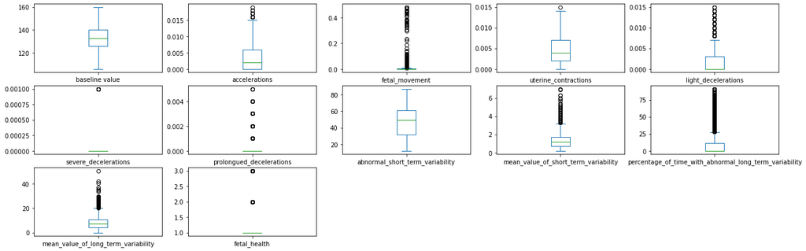

```python
data.plot(kind = "box" , subplots = True , layout= (5,5), figsize =(22,12) )
plt.show()
```

From the graphs above, we can see that there are visible outliers, the most noticeable being in 'percentage_of_time_with_abnormal_long_term_variability' and 'mean_value_of_short_term_variability'. As many machine learning models, like linear and logistic regression, are easily impacted by the outliers in the training data, we are removing the rows for each there is an outlier in any column.

**Remove outliers from data based on z-score**

```python
data = data[(np.abs(stats.zscore(data)) < 3).all(axis=1)]
data
```

|  | baseline value | accelerations | fetal_movement | uterine_contractions | light_decelerations | severe_decelerations | prolongued_decelerations | abnormal_short_term_variability | mean_value_of_short_term_variability | percentage_of_time_with_abnormal_long_term_variability | mean_value_of_long_term_variability | fetal_health |
| --- | --- | --- | --- | --- | --- | --- | --- | --- | --- | --- | --- | --- |
| 0 | 120.0 | 0.000 | 0.000 | 0.000 | 0.000 | 0.0 | 0.0 | 73.0 | 0.5 | 43.0 | 2.4 | 2.0 |
| 1 | 132.0 | 0.006 | 0.000 | 0.006 | 0.003 | 0.0 | 0.0 | 17.0 | 2.1 | 0.0 | 10.4 | 1.0 |
| 2 | 133.0 | 0.003 | 0.000 | 0.008 | 0.003 | 0.0 | 0.0 | 16.0 | 2.1 | 0.0 | 13.4 | 1.0 |
| 3 | 134.0 | 0.003 | 0.000 | 0.008 | 0.003 | 0.0 | 0.0 | 16.0 | 2.4 | 0.0 | 23.0 | 1.0 |
| 4 | 132.0 | 0.007 | 0.000 | 0.008 | 0.000 | 0.0 | 0.0 | 16.0 | 2.4 | 0.0 | 19.9 | 1.0 |
| ... | ... | ... | ... | ... | ... | ... | ... | ... | ... | ... | ... | ... |
| 2121 | 140.0 | 0.000 | 0.000 | 0.007 | 0.000 | 0.0 | 0.0 | 79.0 | 0.2 | 25.0 | 7.2 | 2.0 |
| 2122 | 140.0 | 0.001 | 0.000 | 0.007 | 0.000 | 0.0 | 0.0 | 78.0 | 0.4 | 22.0 | 7.1 | 2.0 |
| 2123 | 140.0 | 0.001 | 0.000 | 0.007 | 0.000 | 0.0 | 0.0 | 79.0 | 0.4 | 20.0 | 6.1 | 2.0 |
| 2124 | 140.0 | 0.001 | 0.000 | 0.006 | 0.000 | 0.0 | 0.0 | 78.0 | 0.4 | 27.0 | 7.0 | 2.0 |
| 2125 | 142.0 | 0.002 | 0.002 | 0.008 | 0.000 | 0.0 | 0.0 | 74.0 | 0.4 | 36.0 | 5.0 | 1.0 |

1824 rows × 12 columns

**Visualizing after outlier removal**

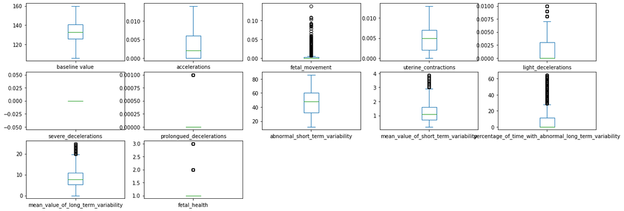

```python
data.plot(kind = "box" , subplots = True , layout= (5,5), figsize =(20,12))
plt.show()
```

It is visible that many outliers have been removed as the outliers in the boxplots for each column have decreased

**Dropping zero-inflated columns**

```python
data = data.drop(columns=['severe_decelerations', 'prolongued_decelerations', 'fetal_movement'])
data
```

|  | baseline value | accelerations | uterine_contractions | light_decelerations | abnormal_short_term_variability | mean_value_of_short_term_variability | percentage_of_time_with_abnormal_long_term_variability | mean_value_of_long_term_variability | fetal_health |
| --- | --- | --- | --- | --- | --- | --- | --- | --- | --- |
| 0 | 120.0 | 0.000 | 0.000 | 0.000 | 73.0 | 0.5 | 43.0 | 2.4 | 2.0 |
| 1 | 132.0 | 0.006 | 0.006 | 0.003 | 17.0 | 2.1 | 0.0 | 10.4 | 1.0 |
| 2 | 133.0 | 0.003 | 0.008 | 0.003 | 16.0 | 2.1 | 0.0 | 13.4 | 1.0 |
| 3 | 134.0 | 0.003 | 0.008 | 0.003 | 16.0 | 2.4 | 0.0 | 23.0 | 1.0 |
| 4 | 132.0 | 0.007 | 0.008 | 0.000 | 16.0 | 2.4 | 0.0 | 19.9 | 1.0 |
| ... | ... | ... | ... | ... | ... | ... | ... | ... | ... |
| 2121 | 140.0 | 0.000 | 0.007 | 0.000 | 79.0 | 0.2 | 25.0 | 7.2 | 2.0 |
| 2122 | 140.0 | 0.001 | 0.007 | 0.000 | 78.0 | 0.4 | 22.0 | 7.1 | 2.0 |
| 2123 | 140.0 | 0.001 | 0.007 | 0.000 | 79.0 | 0.4 | 20.0 | 6.1 | 2.0 |
| 2124 | 140.0 | 0.001 | 0.006 | 0.000 | 78.0 | 0.4 | 27.0 | 7.0 | 2.0 |
| 2125 | 142.0 | 0.002 | 0.008 | 0.000 | 74.0 | 0.4 | 36.0 | 5.0 | 1.0 |

1824 rows × 9 columns

## Preparing the Model

First, we must determine whether we want to stratify our data when splitting it into training and testing datasets. To do this, we will visualize the frequency of each target classification in our cleaned dataset.

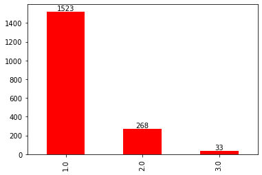

```python
ax = data["fetal_health"].value_counts().plot(kind='bar', color = "red")

for container in ax.containers:
    ax.bar_label(container)
```

This data is imbalanced, since 83% of the data is classified as Normal (1.0). We choose to stratify our data to ensure that the training and testing datasets are assigned some records of each classification. This will ensure that the proportion of data in each classification is preserved, which makes the results reproduceable.

```python
X = data.iloc[:,:-1]
y = data.iloc[:,-1]
X_train, X_test, y_train, y_test = train_test_split(X, y, test_size=0.2, stratify=data["fetal_health"], random_state=45)
#X_train, X_test, y_train, y_test = train_test_split(X, y, test_size=0.2, random_state=45)

X_train.shape, X_test.shape, y_train.shape, y_test.shape
```

```
((1459, 8), (365, 8), (1459,), (365,))
```

```python
print(f'Proportion of each class of fetal health in the original data \n{data["fetal_health"].value_counts() / len(data)}\n\n'+
      f'Proportion of each class of fetal health in the training set\n{y_train.value_counts() / len(y_train)}\n\n'+
      f'Proportion of each class of fetal health in the test set\n{y_test.value_counts() / len(y_test)}')
```

```
Proportion of each class of fetal health in the original data
1.0    0.834978
2.0    0.146930
3.0    0.018092
Name: fetal_health, dtype: float64

Proportion of each class of fetal health in the training set
1.0    0.834818
2.0    0.146676
3.0    0.018506
Name: fetal_health, dtype: float64

Proportion of each class of fetal health in the test set
1.0    0.835616
2.0    0.147945
3.0    0.016438
Name: fetal_health, dtype: float64
```

## Running the Models

We will use 3 models to classify our data: K Nearest Neighbors (KNN), Support Vector Classifier (SVC), and Random Forest. Then we will perform 10 fold cross validation on them to compare the skill of each model.

```python
xdata = data.iloc[:,:-1]
ydata =  data.iloc[:,-1]
```

```python
from sklearn.model_selection import KFold
from sklearn.metrics import accuracy_score
from sklearn.metrics import confusion_matrix, ConfusionMatrixDisplay
from sklearn.model_selection import StratifiedKFold
from sklearn.metrics import f1_score
```

**Model 1**: KNN

```python
from sklearn.neighbors import KNeighborsClassifier
classifier = KNeighborsClassifier(n_neighbors = 5, metric = 'minkowski', p = 2)
classifier.fit(X_train, y_train.values.ravel())
Y_pred = classifier.predict(X_test)

acc = accuracy_score(y_test, Y_pred)
print(acc)
```

```
0.915068493150685
```

For each model, we choose to perform stratified 10 fold validation to ensure that the stratification established in the training and testing datasets is continued and the three classifications are proportionally represented in each of the 10 splits.

```
Accuracy from each fold using KNN with 6 neighbors = [0.9234972677595629, 0.8961748633879781, 0.9234972677595629, 0.8907103825136612, 0.9120879120879121, 0.9010989010989011, 0.9230769230769231, 0.9285714285714286, 0.967032967032967, 0.8901098901098901]
Average accuracy using KNN with 6 neighbors = 0.9155857803398788

The F-scores for each class using KNN =
F-score for Normal fetuses:0.9400630914826499
F-score for Suspect Fetuses 2:0.5909090909090908
F-score for Pathological fetuses:0.0

Confusion Matrix:
```

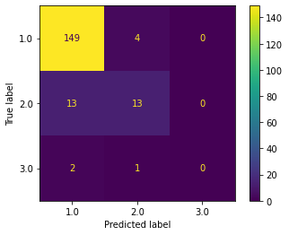

```python
#KNN - 10 fold validation
kf = StratifiedKFold(n_splits=10,random_state=40, shuffle=True)
accscore = []
classifier = KNeighborsClassifier(n_neighbors = 6, metric = 'minkowski', p = 2)

for train_index , test_index in kf.split(xdata, ydata):
    X_train , X_test = xdata.iloc[train_index],xdata.iloc[test_index]
    y_train , y_test = ydata.iloc[train_index] , ydata.iloc[test_index]

    #classifier.fit(X_train,y_train)
    classifier.fit(X_train, y_train.values.ravel())
    y_pred = classifier.predict(X_test)

    acc = accuracy_score(y_test, y_pred)
    accscore.append(acc)

avgscore = sum(accscore)/10

print("Accuracy from each fold using KNN with 6 neighbors = " + str(accscore))
print("Average accuracy using KNN with 6 neighbors = " + str(avgscore))
print()


fscore = f1_score(y_test, y_pred, average=None)

print("The F-scores for each class using KNN =")
print("F-score for Normal fetuses:" + str( fscore[0]))
print("F-score for Suspect Fetuses 2:" + str( fscore[1]))
print("F-score for Pathological fetuses:" + str( fscore[2]))
print()
print("Confusion Matrix:")
cm = confusion_matrix(y_test, y_pred)
disp = ConfusionMatrixDisplay(confusion_matrix=cm, display_labels=classifier.classes_)
disp.plot()
plt.show()
```

**Model 2**: SVC

```python
 # another model
from sklearn.svm import SVC
classifier1 = SVC(kernel = 'linear', random_state = 40)
classifier1.fit(X_train, y_train.values.ravel())
Y_pred = classifier1.predict(X_test)
acc1 = accuracy_score(y_test, Y_pred)
acc1
```

```
0.8956043956043956
```

```
Accuracy from each fold using SVM = [0.8907103825136612, 0.8579234972677595, 0.8797814207650273, 0.8360655737704918, 0.9065934065934066, 0.8901098901098901, 0.9175824175824175, 0.9010989010989011, 0.9065934065934066, 0.8956043956043956]
Average accuracy using SVM = 0.8882063291899358

The F-scores for each class using SVM =
F-score for Normal fetuses:0.939297124600639
F-score for Suspect Fetuses 2:0.6666666666666667
F-score for Pathological fetuses:0.0

Confusion Matrix:
```

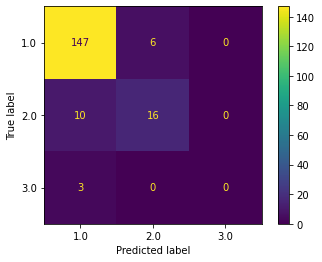

```python
#SVM - 10 fold validation
kf = StratifiedKFold(n_splits=10, random_state=40, shuffle=True)
accscore = []
classifier1 = SVC(kernel = 'linear', random_state = 40)

for train_index , test_index in kf.split(xdata, ydata):
    X_train , X_test = xdata.iloc[train_index],xdata.iloc[test_index]
    y_train , y_test = ydata.iloc[train_index] , ydata.iloc[test_index]

    classifier1.fit(X_train, y_train.values.ravel())
    y_pred = classifier1.predict(X_test)

    acc = accuracy_score(y_test, y_pred)
    accscore.append(acc)

avgscore = sum(accscore)/10

print("Accuracy from each fold using SVM = " + str(accscore))
print("Average accuracy using SVM = " + str(avgscore))
print()
fscore = f1_score(y_test, y_pred, average=None)
print("The F-scores for each class using SVM =")
print("F-score for Normal fetuses:" + str( fscore[0]))
print("F-score for Suspect Fetuses 2:" + str( fscore[1]))
print("F-score for Pathological fetuses:" + str( fscore[2]))
print()
print("Confusion Matrix:")
cm = confusion_matrix(y_test, y_pred)
disp = ConfusionMatrixDisplay(confusion_matrix=cm, display_labels=classifier1.classes_)
disp.plot()
plt.show()
```

**Model 3**: Random Forest

```python
from sklearn.ensemble import RandomForestClassifier
classifier2 = RandomForestClassifier(n_estimators = 10, criterion = 'entropy', random_state = 40)
classifier2.fit(X_train, y_train.values.ravel())
Y_pred = classifier2.predict(X_test)
acc2 = accuracy_score(y_test, Y_pred)
acc2
```

```
0.9230769230769231
```

```
Accuracy from each fold using Random Forest = [0.9289617486338798, 0.9398907103825137, 0.9453551912568307, 0.9234972677595629, 0.945054945054945, 0.9340659340659341, 0.9395604395604396, 0.967032967032967, 0.967032967032967, 0.9230769230769231]
Average accuracy using Random Forest = 0.9413529093856964

The F-scores for each class using Random Forest =
F-score for Normal fetuses:0.9587301587301588
F-score for Suspect Fetuses 2:0.7111111111111111
F-score for Pathological fetuses:0.5

Confusion Matrix:
```

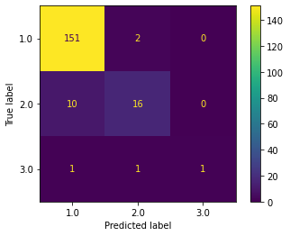

```python
kf = StratifiedKFold(n_splits=10, random_state=40, shuffle=True)
accscore = []
classifier2 = RandomForestClassifier(n_estimators = 10, criterion = 'entropy', random_state = 40)


for train_index , test_index in kf.split(xdata, ydata):
    X_train , X_test = xdata.iloc[train_index],xdata.iloc[test_index]
    y_train , y_test = ydata.iloc[train_index] , ydata.iloc[test_index]

    classifier2.fit(X_train, y_train.values.ravel())
    Y_pred = classifier2.predict(X_test)


    acc2 = accuracy_score(y_test, Y_pred)
    accscore.append(acc2)

avgscore = sum(accscore)/10

print("Accuracy from each fold using Random Forest = " + str(accscore))
print("Average accuracy using Random Forest = " + str(avgscore))
print()


fscore = f1_score(y_test, Y_pred, average=None)

print("The F-scores for each class using Random Forest =")
print("F-score for Normal fetuses:" + str( fscore[0]))
print("F-score for Suspect Fetuses 2:" + str( fscore[1]))
print("F-score for Pathological fetuses:" + str( fscore[2]))
print()
print("Confusion Matrix:")
cm = confusion_matrix(y_test, Y_pred)
disp = ConfusionMatrixDisplay(confusion_matrix=cm, display_labels=classifier2.classes_)
disp.plot()
plt.show()
```

Similar to the SVC model, the Random Forest model's accuracy for predicting Suspect (2.0) is better than that of KNN. This model's predictions for Normal (1.0) fetuses are more accurate than both KNN and SVC as the number of true positives are higher and the number of false negatives are lower. Additionally, this is the only model that is able to correctly classify a datapoint as Pathological (3.0). This could be because Random Forest uses several decision trees, making it better suited for a non-binary classification like this.

## Results

**Accuracy score:**

Random Forest was the classifier with the highest average accuracy at ~94.1%. KNN was a close second at ~91.5% and SVC had the lowest accuracy of the three at ~88.8%

**F-score** As this is an imbalanced dataset, we recognize that accuracy might not be the best measure of how well a model functions. Thus, we choose to implement the F-score as well. Here, we can see how well each model functions for each class. We saw that all 3 models performed extremely well to classify Normal fetuses, mediocre for Suspect fetuses, and not well at all for Pathological fetuses. This tells us that our models did not function well for classifying Pathological fetuses, and this could be because we did not have enough data to train it well on.

## Conclusion

Through the process of understanding and performing fetal health classification, we traversed our way through the data science pipeline. We started off with labeled data with 3 classes - normal, suspect, and pathological. We identified that it was an imbalanced dataset, so we would have to take further precautions as we went along. After identifying this target variable, we conducted some exploratory analysis and visualizations to understand our data - the spread, correlation etc. with the target variable. Next, we cleaned our data - removing possibly misleading columns and outliers from our data. We then created 3 different kinds of machine learning models- K-nearest neighbors, SVC, and Random forest - to classify this data. After running these ML models, we are now able to present our insights and takeaways.

As it was an imbalanced dataset skewed towards Normal fetuses, we realized that a regular K-fold cross validation did not give us an accurate representation. Therefore, we switched gears and decided to implement a stratified K-fold cross validation on our target variable. We even recognized that accuracy may not be the most representative in this case, and displayed the F1-score as well.

## Policy Recommendation

As we were able to classify fetuses into these 3 classes fairly well using this CTG data and see a lot of potential in this method, our policy recommendation for the future would be to maximize the utilization of CTGs, especially in low-income, and low-resource areas as this would help give a clearer picture of the fetus’ health and in turn the mother’s health as well. If we are able to identify that a fetus’ health is suspect or pathological through this CTG data, appropriate steps can then be taken by healthcare professionals in achieving the best outcome for the mother and the fetus. Furthermore, the more CTG data we have, the more accurate future ML models can be made as well, paving the way to saving more lives. AS even our best model (Random forest) is not great at classifying the Pathological fetuses - the smallest proportion, having more CTG data would help make the model's prediction better as we would then have more data for pathological fetuses.